# Predicting BMW Stock Price Direction Using Machine Learning

## 2.1 Missing Data

```r
# Count missing values per column
missing_summary <- bmw %>%
  summarise(across(everything(), ~ sum(is.na(.)))) %>%
  pivot_longer(everything(),
               names_to = "Variable", values_to = "Missing") %>%
  filter(Missing > 0) %>%
  mutate(Pct = round(Missing / nrow(bmw) * 100, 2)) %>%
  arrange(desc(Missing))

if (nrow(missing_summary) == 0) {
  cat("No missing values detected in any column.\n")
} else {
  knitr::kable(missing_summary,
               caption = "Table 0. Variables with missing values")
}
```

```
## No missing values detected in any column.
```

```r
# Check for Inf values
inf_cols <- bmw %>%
  summarise(across(where(is.numeric), ~ sum(is.infinite(.)))) %>%
  pivot_longer(everything(),
               names_to = "Variable", values_to = "Inf_Count") %>%
  filter(Inf_Count > 0)

if (nrow(inf_cols) > 0) {
  cat("\nColumns with Inf/-Inf values:\n")
  print(inf_cols)
}
```

```
##
## Columns with Inf/-Inf values:
## # A tibble: 1 × 2
##   Variable      Inf_Count
##   <chr>             <int>
## 1 Volume_Change       106
```

The dataset contains no traditional missing (NA) values: all 7,390 rows are complete. However, the `Volume_Change` column contains `Inf` and `-Inf` values on days when the previous day’s trading volume was zero (division by zero). These infinite values cannot be normalised or used by any of our models. We therefore remove `Volume_Change` entirely from the modelling pipeline before fitting any model. The information it was meant to capture (relative volume change) is partially represented by `Volume_MA7`, which remains in the predictor set.

The moving average and volatility features (`MA7`, `MA30`, `Volatility_7`, etc.) require a warm-up period of 7–30 trading days before they can be computed. Any resulting NAs in the first few rows are handled by `step_impute_median()` in the recipe.

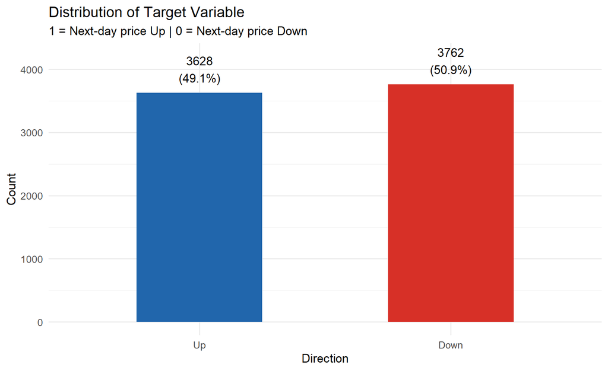

Figure 1. Class balance of the Target variable.

```r
bmw %>%
  count(Target) %>%
  mutate(pct = n / sum(n) * 100) %>%
  ggplot(aes(x = Target, y = n, fill = Target)) +
  geom_col(width = 0.5, show.legend = FALSE) +
  geom_text(aes(label = sprintf("%d\n(%.1f%%)", n, pct)),
            vjust = -0.4, size = 4.5) +
  scale_fill_manual(values = c("Up" = "#2166ac", "Down" = "#d73027")) +
  scale_y_continuous(limits = c(0, 4200)) +
  labs(
    title = "Distribution of Target Variable",
    subtitle = "1 = Next-day price Up | 0 = Next-day price Down",
    x = "Direction",
    y = "Count"
  ) +
  theme_minimal(base_size = 13)
```

The dataset is remarkably balanced: 3,628 “Up” days (49.1%) vs. 3,762 “Down” days (50.9%). This near-perfect balance means that a naive classifier that always predicts “Down” achieves only 50.9% accuracy. It also means that class-imbalance corrections are not required.

## 2.2 BMW Closing Price Over Time

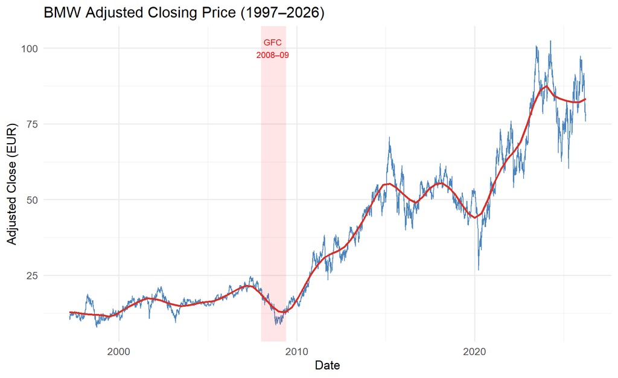

Figure 2. BMW adjusted closing price 1997–2026.

```r
bmw %>%
  ggplot(aes(x = Date, y = `Adj Close`)) +
  geom_line(color = "#2166ac", alpha = 0.8, linewidth = 0.4) +
  geom_smooth(method = "loess", span = 0.15,
              color = "#d73027", se = FALSE, linewidth = 1) +
  labs(
    title   = "BMW Adjusted Closing Price (1997–2026)",
    x       = "Date",
    y       = "Adjusted Close (EUR)"
  ) +
  theme_minimal(base_size = 13) +
  annotate("rect", xmin = as.Date("2008-01-01"),
           xmax = as.Date("2009-06-01"),
           ymin = -Inf, ymax = Inf,
           alpha = 0.1, fill = "red") +
  annotate("text", x = as.Date("2008-09-01"), y = 100,
           label = "GFC\n2008–09", size = 3.2, color = "red")
```

## 2.3 Daily Return Distribution by Target Class

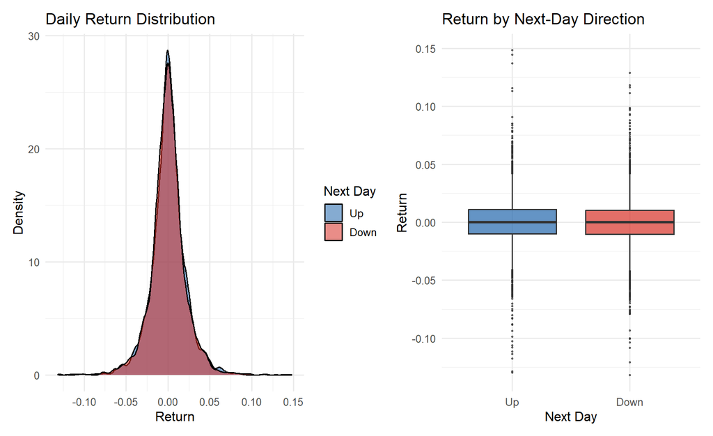

Figure 3. Daily return distributions for Up vs Down days.

```r
p1 <- bmw %>%
  ggplot(aes(x = Return, fill = Target)) +
  geom_density(alpha = 0.55) +
  scale_fill_manual(values = c("Up" = "#2166ac", "Down" = "#d73027")) +
  labs(title = "Daily Return Distribution",
       x = "Return", y = "Density", fill = "Next Day") +
  theme_minimal(base_size = 12)

p2 <- bmw %>%
  ggplot(aes(x = Target, y = Return, fill = Target)) +
  geom_boxplot(alpha = 0.7, outlier.size = 0.5, show.legend = FALSE) +
  scale_fill_manual(values = c("Up" = "#2166ac", "Down" = "#d73027")) +
  labs(title = "Return by Next-Day Direction",
       x = "Next Day", y = "Return") +
  theme_minimal(base_size = 12)

p1 + p2
```

Both distributions are centred near zero and nearly symmetrical, consistent with the efficient market hypothesis. However, “Up” days exhibit a slightly higher mean return (0.063%) vs. “Down” days (0.013%), suggesting a weak positive momentum signal. The market tends to continue rising on days following small gains.